# An Analysis of Temperature and Atmosphere on the Properties of Fly Ash Particles

Gavin Scoville

2025-07-16

## 1 Introduction

This paper demonstrates how statistical techniques can be a tool for tackling engineering problems in chaotic problem spaces. The dataset regards coal fly ash particles: a recycled, non-homogeneous, non-engineered powder left after burning coal. The data in this paper comes from the study “Effect of temperature and atmosphere on the optical, thermal, and structural properties” by Dr. Glosser et al.

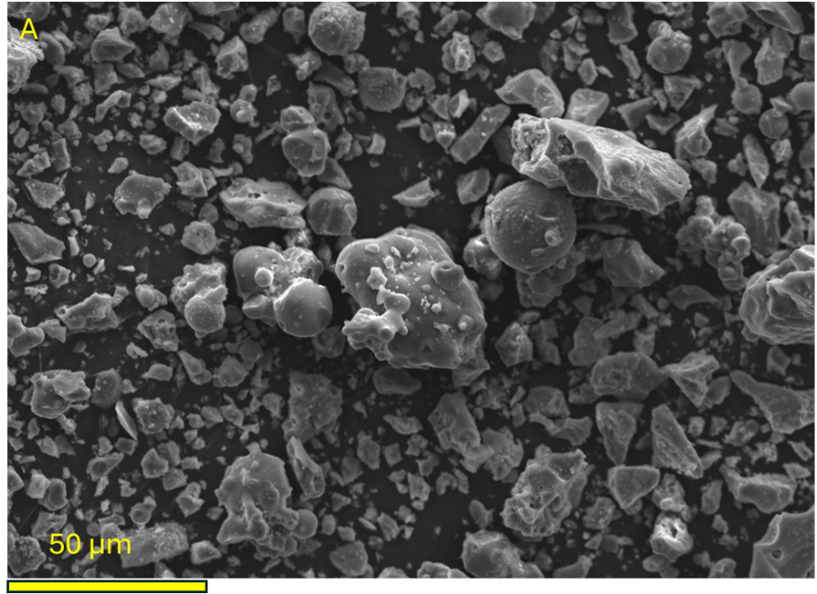

Scanning electron images of Ash M cycled in air at 1000ºC at 500x magnification Above. Image taken by Dr. Glosser.

The motivation behind the study is to improve the usability of coal fly ash as a recycled material for thermal energy storage (TES) systems. The data compares the effects of thermal cycling in air (oxidizing), argon (inert, non-oxidizing), and nitrogen (quasi-inert, non-oxidizing) atmospheres on the solar absorption, specific heat capacity, micro structure, and crystallinity of coal fly ash particles. Note that the raw data is sensitive and not shared at this time. All results are based on locally stored data.

### 1.1 High Temp Particulate Materials

High temperature particulate materials are powders or other particulate materials that can sustain high temperatures (in this case, 1000°C). Their specific heat and stability at high temperatures makes them useful for sensible thermal energy storage (TES) applications. Concentrated Solar Power systems use a TES in order to store the thermal energy captured by the sun. With proper insulation, these high temperature particles are useful in generating electricity up to a month after exposure to concentrated solar power. The implication of this technology is that we can create cost-effective concentrating solar power systems that can store thermal energy, only converting it to electrical energy at times when the grid needs it most. This addresses one of the most formidable challenges in the transition to clean energy grid.

Using fly ash, a waste product of burning coal, could provide a more cost effective and sustainable substrate then engineered bauxite beads; the current standard . This study aims to determine what qualities of fly ash, and what cycle conditions create optimal conditions for CSP technology. The data describes many instances where recycled Fly Ash is able to outperform the current standards set by engineered bauxite beads.

Statistical learning techniques are useful in this problem because the properties of heterogeneous Coal Fly Ash are highly variable, sometimes outperforming bauxite beads, but oftentimes rendering it unsuitable for CSP. Statistical Learning Techniques allow us to analyze higher dimensions, and explore the complicated 15-dimensional independent variable space for useful patterns. This report identifies several instances where Coal Fly Ash is a promising substrate for Thermal Energy Storage Systems (TES).

### 1.2 Analysis Pipeline

Hypothesis testing

Classical linear regression

Multiple linear regression

Lasso regression

Regression Trees

while incorporated principle component analysis (PCA) where appropriate.

Across the board, regression trees offered the most competitive models. Regression Trees can explain nearly as high a percentage of variance in the model. They are excellently interpretable. The assumptions of their models are not violated. Due to the low number of samples, and early stage of research on this topic, we are prioritizing interpretable models over out-of-bag mean-squared-error minimizing models. Future work seeking to prioritize predictive abilities should investigate other non-parametric models such as an N Nearest Neighbors model, random forests, and neural networks.

## 2 Preliminary Description of the Study

A fly ash that is a suitable substrate for a concentrated solar power system (CSP) with thermal energy storage, will have three traits:

1. *High Solar Absorptance.* This means it will efficiently capture the energy from the sun. This was measured with a spectrometer, and we applied AM1.5 solar absorptance weights to represent how it would preform under a standardized solar spectrum. To be a viable competitor to bauxite, we need a solar absorptance above 85%, and the higher the better.
2. *High Chemical Stability.* We represented chemical stability with how crystalline the fly ash is. The more crystalline a material, the more thermodynamically stable it is at high temperature. Moreover, crystalline materials are more resistant to thermal shock and structural breakdown than amorphous materials, which will help extend the useful life of the fly ash in a TES. We measured the degree of crystallinity as the ratio of peaks:amorphous lump of the spectrum captured by an X-ray difractogram).
3. *High Specific Heat Capacity.* Specific heat capacity is important for a TES substrate, because it is proportional to how much energy the particles are actually going to store and exchange in the heat exchanger. We measured this with substrate held at 550°C to accurately simulate the TES environment. Current state of the art TES bauxite particles have specific heat capacities measured between 1.2 J/g°C and 1.3 J/g°C at temperatures above 500°C .

### 2.1 Absorptance

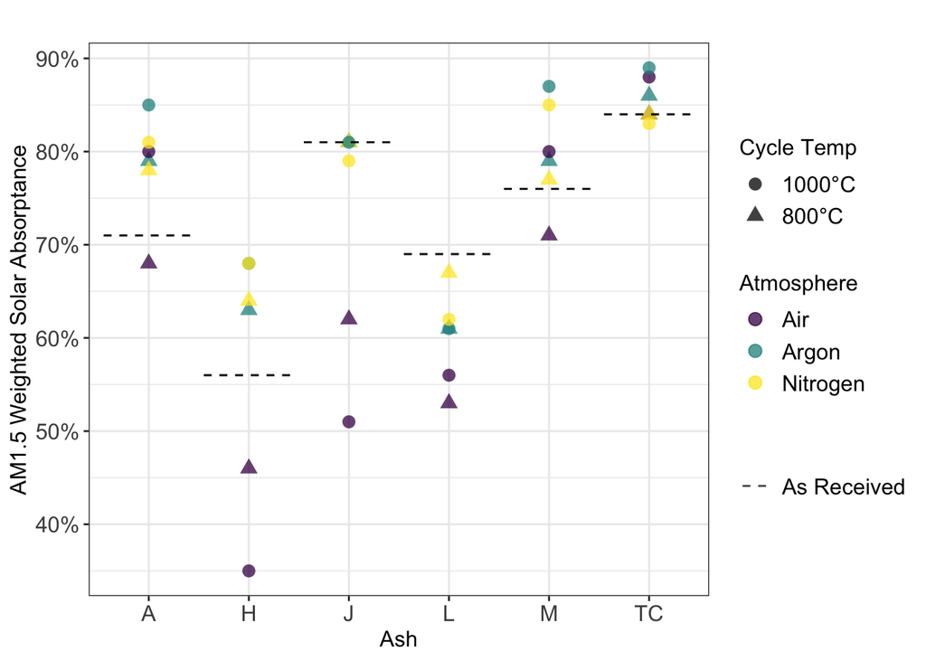

The above figure demonstrates each fly ash’s Absorptance (% of sunlight energy captured)

Fly ashes cycled in Air had generally lower Absorptance rates. These fly ashes also tended to look lighter colored and oranger. The best explanation for this is that in an oxidizing environment, iron specimens transitioned from forms that are black (like magnetite) to forms that are red (like hematite), who’s spectrum was identified in the samples using X-ray Diffraction.

### 2.2 Crystallinity:

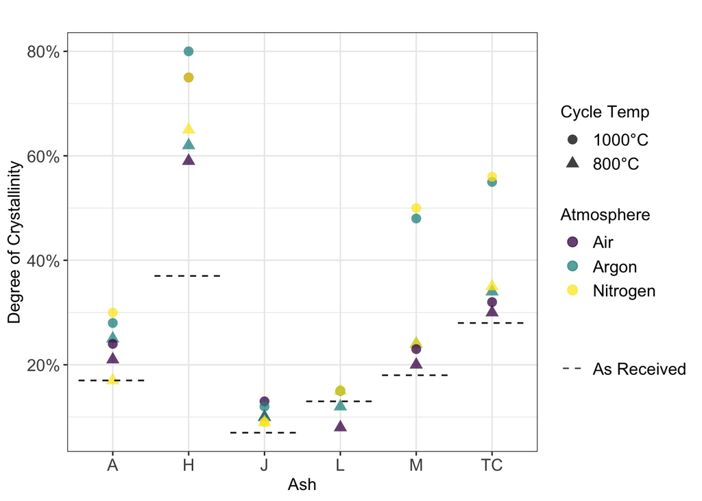

The above figure visualizes how the % crystallinity of each ash changes in each experimental condition.

Generally speaking, higher temperatures result in more crystalline fly ashes. As a trend, but not a rule, Argon and Nitrogen treatments result in more crystalline fly ashes, especially at 1000°C.

### 2.3 Specific Heat Capacity:

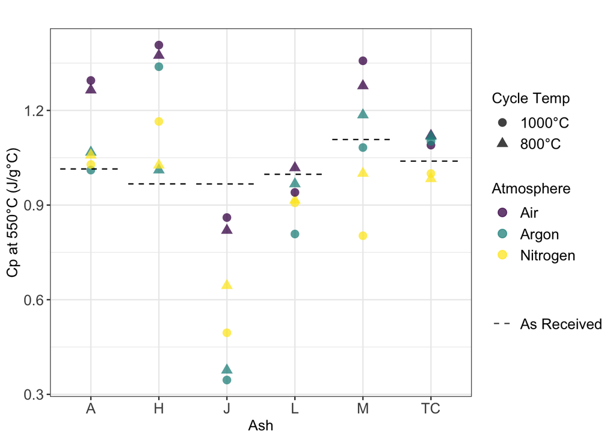

The above figure demonstrates how Specific Heat capacity varies across experimental conditions.

The Coal Fly ash often meets or exceeds the specific heat capacity of bauxite particles. We can also observe a trend in that particles fired in air have generally higher heat capacity, and that change from the as received composition is generally higher when fired all the way to 1000°C. Comparing this to Absorptance, we can see that generally heat capacity has an inverse relationship with Absorptance. This is likely driven by the fact that iron, the element most associated with high absorption, has a low heat capacity. More on this when it comes to modeling.

### 2.4 Multicolinearity in the Data

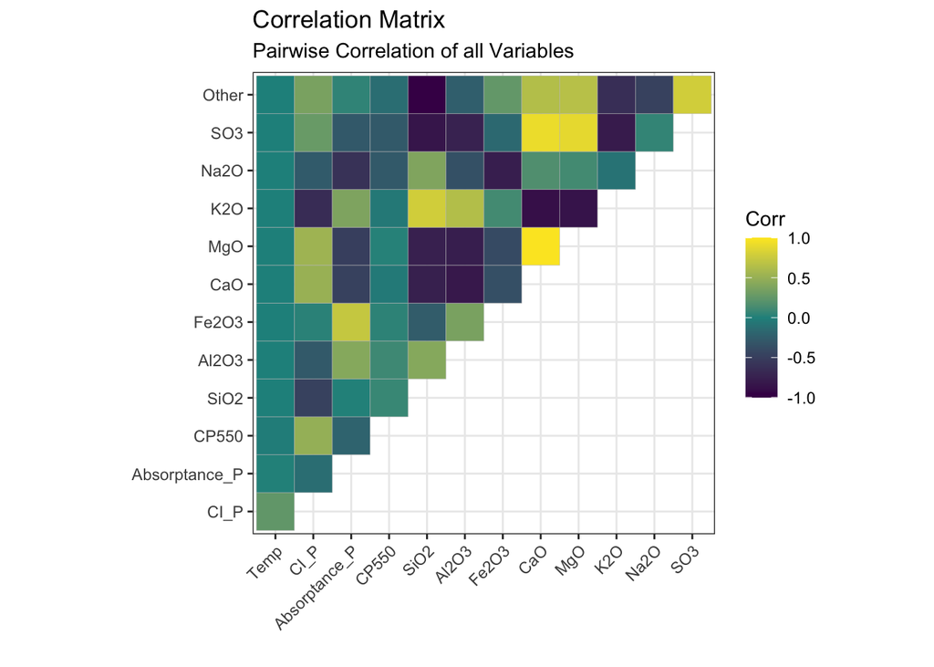

Here we can see a correlation plot of all the independent variables and dependent variables involved in our study. There are a few key points to note. First, Crystallinity (CI_P, a dependent variable) is correlated with Specific Heat capacity at 550°C (CP550, another dependent variable). This is good news for us because when optimizing for highly crystalline, high specific heat capacity particles, we might be able to get both with one treatment.

Unfortunately, Absorptance has a weak negative correlation with both crystallinity and specific heat capacity. This is not great news, as it means that unless we can find a more nuanced and tunable relationship, we might have to weigh the trade offs between a stable, crystalline, high heat capacity fly ash, and a fly ash that captures solar energy efficiently. The opportunity to tune the fly ash is another reason why statistical modeling can be helpful.

One challenge in modeling this data is the strong correlation between our bulk composition variables. This means we are facing multicolinearity. For example, if CaO has a .92 correlation with SO3. Thus in observations where CaO is increased, SO3 is also increases proportionally, most of the time. We don’t have any reliable no way to tell if it is SO3 or CaO which is causing changes in the dependent variable. You can beat mulicolinearity with enough data, but with only 42 observations our models are going to be unstable.

The extreme of multicolinearity is perfect mulitcolinearity. We have 9 bulk compositions variables, but the rank of our design matrix is only 6, making a large MLR model impossible. To mitigate the effect of such little data, we can utilize techniques including PCA, lasso regression, tree based methods, cross validation, and bootstrapping techniques. Each approach comes with it’s own strengths and weaknesses, as discussed below.

### 2.5 Principle Component Analysis:

Principle Component Analysis is a helpful tool that reduces the dimensions of our 9-dimensional bulk composition data. This hopefully concentrates the signal, making analysis more robust, at the cost of interpretability. PCA involves fitting an 9-dimensional hyper-plane to the data, so that each additional dimension minimizes the remaining variance in the data. The result is a series of 9 principle components, each one a linear combination of the composition variables (called it’s rotation), and each observation is left with a value for it’s principle components (called the score) that describe the observation in terms of the components that contribute most strongly to the variance in the data.

It’s common to scale the data before applying PCA, but in this case I chose not to, since bulk composition is already measured in % total, and I didn’t want to inflate the importance of bulk materials with very little magnitude and variance, thus amplifying noise in the data and making the results less interpretable.

```r
sum(pve[1:2])
```

```
## [1] 0.9672622
```

In this case, the first two principle components describe almost 97% of the variance in Bulk Composition in our fly ashes. We can see the composition as follows:

```r
pr.out$rotation[,1:2]
```

```
##               PC1         PC2
## SiO2   0.79603645  0.31800110
## Al2O3  0.12890117 -0.24009745
## Fe2O3 -0.02816576 -0.72155385
## CaO   -0.50792513  0.50879084
## MgO   -0.14158130  0.14878065
## K2O    0.04768408 -0.02453674
## Na2O   0.02004400  0.12793965
## SO3   -0.06106554  0.03002746
## Other -0.25392797 -0.14735165
```

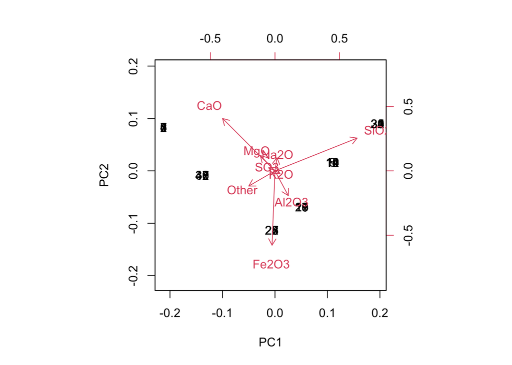

```r
biplot(pr.out,choices = 1:2,scale=F)
```

```r
pr.out$rotation[,1:4]
```

```
##               PC1         PC2         PC3         PC4
## SiO2   0.79603645  0.31800110 -0.17841846  0.07017639
## Al2O3  0.12890117 -0.24009745  0.64434657 -0.59231603
## Fe2O3 -0.02816576 -0.72155385 -0.57132198 -0.13930596
## CaO   -0.50792513  0.50879084 -0.27364928 -0.30073643
## MgO   -0.14158130  0.14878065  0.00271800 -0.04137730
## K2O    0.04768408 -0.02453674  0.03692654  0.37583463
## Na2O   0.02004400  0.12793965 -0.02803382 -0.15593407
## SO3   -0.06106554  0.03002746 -0.01880721  0.21855399
## Other -0.25392797 -0.14735165  0.38623963  0.56510478
```

The first principle component (PC1) is *mostly the contrast between SiO2* (an acidic oxide) *and CaO* (A basic oxide). The ratio between these molecules plays an pivotal role in the material properties of ceramics, metallurgy, cement manufacturing. We can interpret PC1 as mostly a measure of this contrast, with a higher PC1 meaning a more acidic, SiO2 ash.

We can interpret the second principle component as *mostly the content of Fe2O3* with some contribution from the % Al2O3, in slight contrast with SiO2. A negative PC2 means higher Iron content.

## 3 Modeling the Data

### 3.1 Absorptance

Iron content is by far the greatest predictor of a fly ash Absorptance rate. Iron content alone explains 54% of the variance in the data.

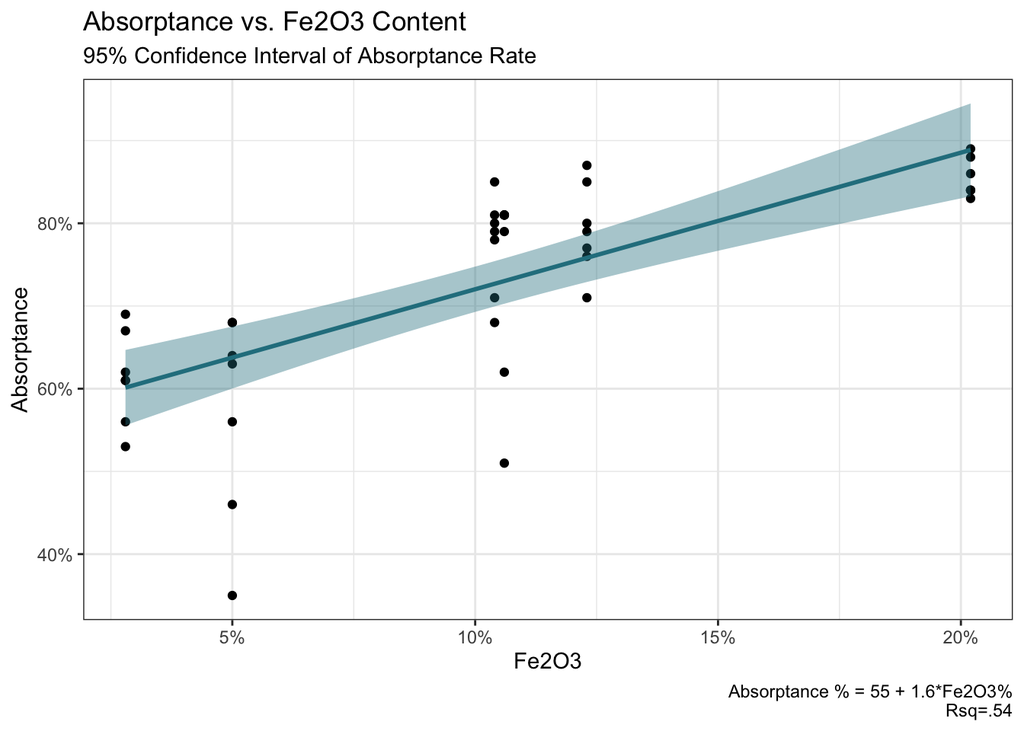

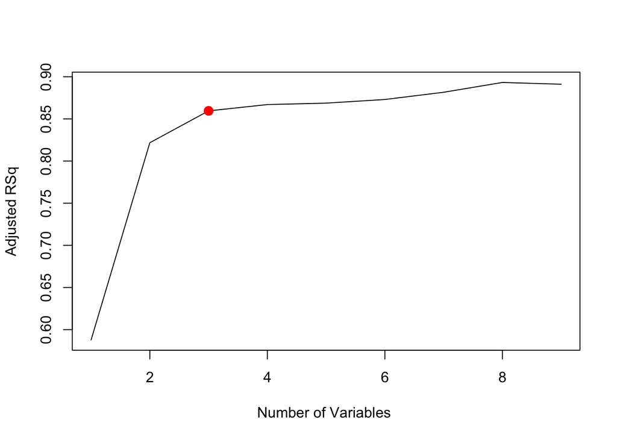

```
##
## Call:
## lm(formula = Absorp ~ Treatment + Fe2O3 + K2O, data = df)
##
## Residuals:
##       Min        1Q    Median        3Q       Max
## -0.142749 -0.035473 -0.004186  0.048767  0.110873
##
## Coefficients:
##                Estimate Std. Error t value Pr(>|t|)
## (Intercept)     0.48304    0.03627  13.319 1.09e-15 ***
## TreatmentInert  0.03375    0.02808   1.202 0.236980
## TreatmentAir   -0.08333    0.03076  -2.709 0.010151 *
## Fe2O3           1.56967    0.17157   9.149 4.89e-11 ***
## K2O             4.85290    1.23888   3.917 0.000372 ***
## ---
## Signif. codes:  0 '***' 0.001 '**' 0.01 '*' 0.05 '.' 0.1 ' ' 1
##
## Residual standard error: 0.06151 on 37 degrees of freedom
## Multiple R-squared:  0.7891, Adjusted R-squared:  0.7663
## F-statistic: 34.61 on 4 and 37 DF,  p-value: 4.888e-12
```

Our best MLR and can begin to describe 79% of the variance in the data. This is a significant improvement in the model (F statistic >7). Inert gasses improve absorptance by nearly 12% (p(type1 error)<.000) over air counterparts, all else held equal. Every 1% increase in Iron content increases Absorptance by 1.57%, all else held equal. Every 1% increase in K2O increases Absorptance by 4.9%, all else help equal. However, the results of this model are not conclusive, as K2O is highly correlated with SiO2, and inversely correlated with CaO, SO3, and MgO. Without more data, we can’t conclusively untangle these relationships. Accepting this known unknown, we can use PCA to make a more stable model with less chance of type 1 error. We can use ridge regression to manage variance-bias trade off, and we can use cross-validation to protect ourselves from over-fitting.

```
## integer(0)
```

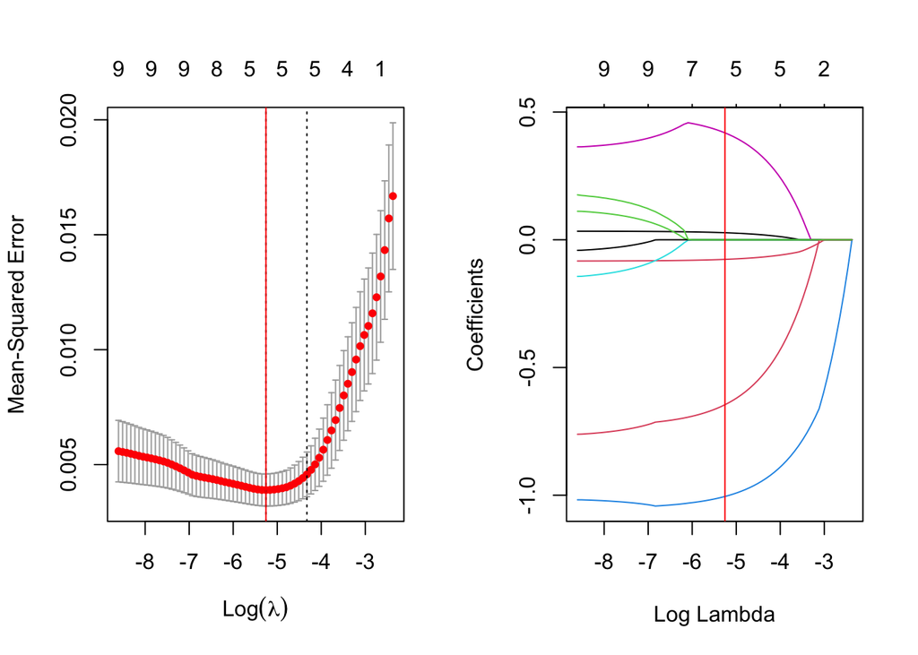

```
## integer(0)
```

We can see that a shrinkage penalty of about -5.2 provides the best trade off between bias and variance. We are left with 6 variables:

```
##      (Intercept)   TreatmentInert     TreatmentAir              PC2
##       0.72995031       0.02760395      -0.07670066      -1.00505958
## TreatmentAir:PC1 TreatmentAir:PC2
##       0.41864247      -0.64577531
```

Despite our best efforts to create robust models, we are still attempting to model a highly bifurcated, kinetic process. Our residuals are not normally distributed, and instead come in odd groupings, implying that the assumptions of our model are being violated.

A good solution is to use Regression Trees. In Regression trees, we divide the predictor space up into a set of non-overlapping boxes (sometimes high-dimensional boxes) by recursive binary splitting. The means we just keep slicing the predictor space into nested regions, so that each region describes our dependent variable as well as possible.

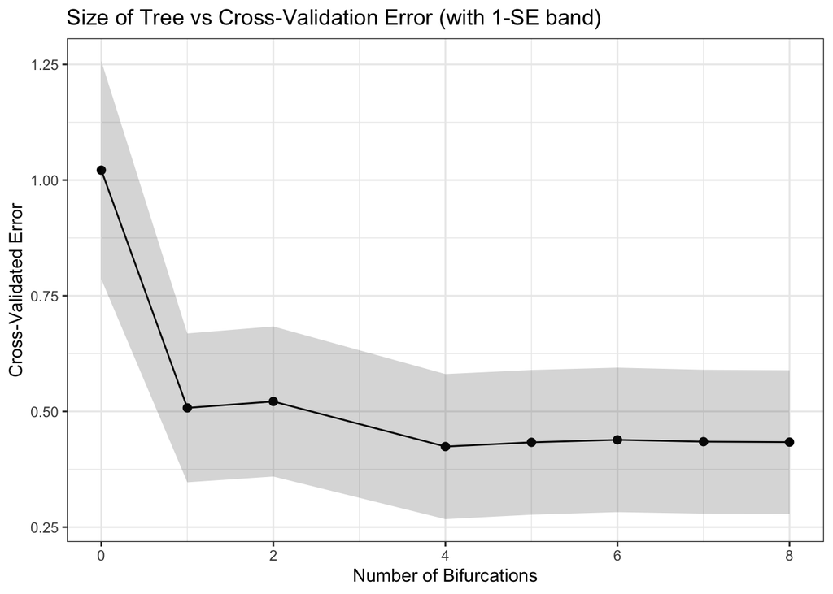

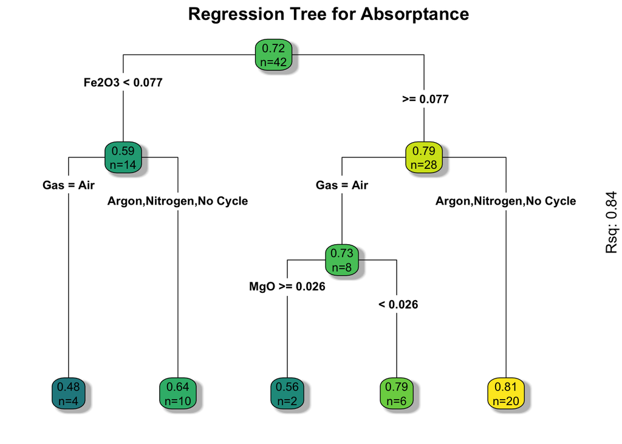

### 3.2 Degree of Crystallinity

Following a very similar pipeline to modeling absorptance, we are able to uncover a few valuable pieces of information worth noting:

```
##
##  Paired t-test
##
## data:  dfog$CI[Temp800] and dfog$CI[Temp1000]
## t = -4.5721, df = 17, p-value = 0.0002707
## alternative hypothesis: true mean difference is not equal to 0
## 95 percent confidence interval:
##  -0.14208548 -0.05235896
## sample estimates:
## mean difference
##     -0.09722222
```

We find evidence consistent with the alternative hypothesis, that there is a difference between samples cycled at 800°C and samples cycled at 1000°C. We estimate that samples cycled to 1000°C are about 9.7% more crystalline, on average. We cannot conclude that different atmospheres cause a statistically significant difference in crystallinity index.

We also find that MgO and K2O are the two molecules that best predict the degree of crystallinity. Unfortunately, due to the multicolinearity of these molecules in the dataset, we cannot use our data to determine which is responsible for the degree of crystallinity. This makes our models unstable/not robust. While our the models might flip between one or the other to explain crystallization due to multicolinearity in the dataset, both properties likely ring true. MgO is known to form strong ionic bonds and high lattice energy, while K2O is much more reactive, and commonly used to reduce crystallization in optical glasses. For simplicity, I will choose to omit MgO from tree modeling, knowing that a high K2O concentrations also imply a low MgO fly ash in our particular dataset.

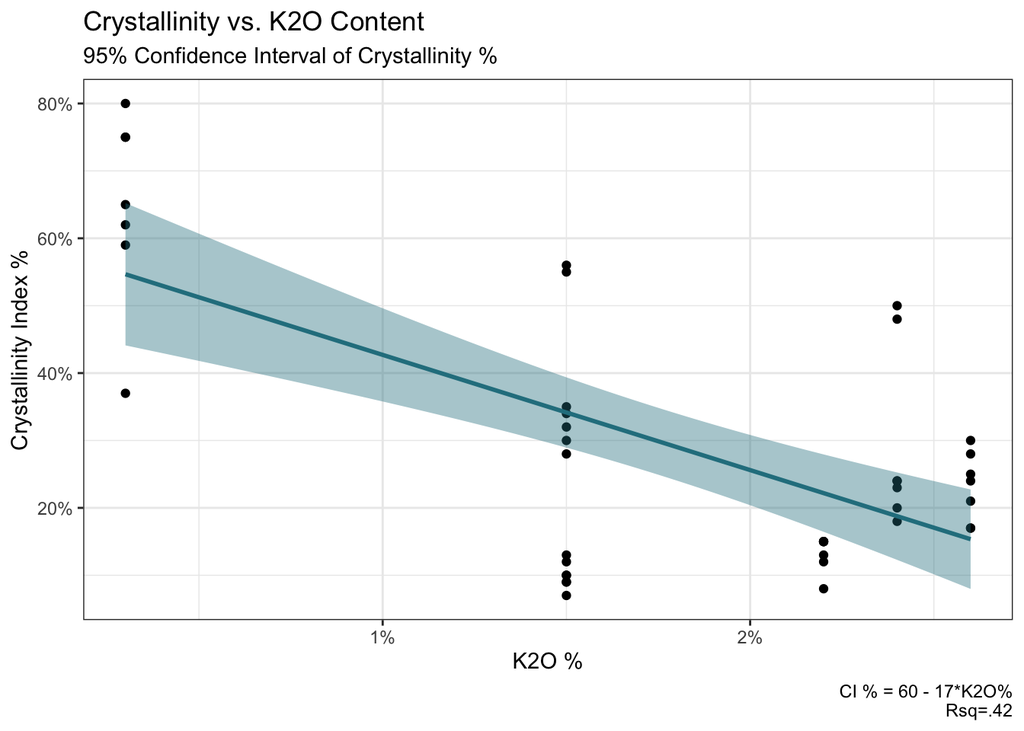

We can expand this model into the model selected by forward subset selection. Minimizing adjusted Rsqu, is the following MLR:

```
##
## Call:
## lm(formula = CI ~ Temp + CaO + K2O + Na2O + SO3, data = df)
##
## Residuals:
##       Min        1Q    Median        3Q       Max
## -0.178552 -0.042697 -0.004252  0.037559  0.137596
##
## Coefficients:
##              Estimate Std. Error t value Pr(>|t|)
## (Intercept)   0.62332    0.08925   6.984 4.01e-08 ***
## Temp800       0.06667    0.03440   1.938   0.0607 .
## Temp1000      0.16389    0.03440   4.765 3.26e-05 ***
## CaO           3.24765    0.50897   6.381 2.44e-07 ***
## K2O         -17.31632    3.29702  -5.252 7.48e-06 ***
## Na2O         -7.78790    1.00766  -7.729 4.50e-09 ***
## SO3         -30.92138    3.28378  -9.416 3.99e-11 ***
## ---
## Signif. codes:  0 '***' 0.001 '**' 0.01 '*' 0.05 '.' 0.1 ' ' 1
##
## Residual standard error: 0.07297 on 35 degrees of freedom
## Multiple R-squared:  0.8931, Adjusted R-squared:  0.8748
## F-statistic: 48.74 on 6 and 35 DF,  p-value: 1.48e-15
```

We can more rigorously defend the model from over-fitting by instead using a Lasso Regression to select our coefficients:

```
## integer(0)
```

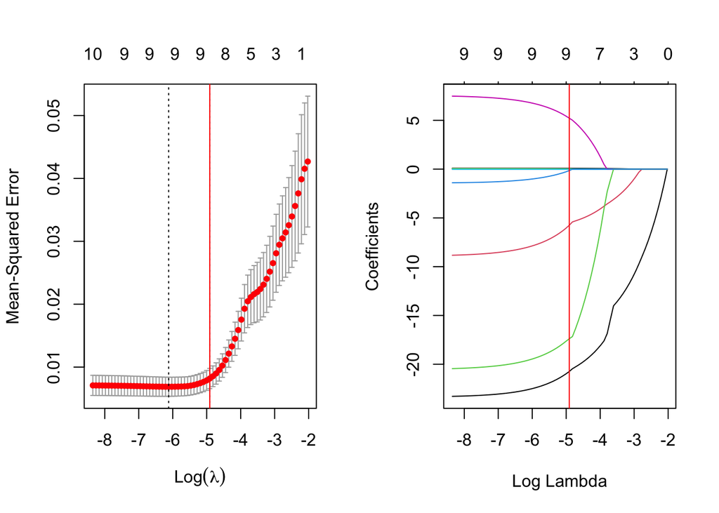

```
## integer(0)
```

```
##  (Intercept)     Temp1000     GasArgon  GasNitrogen  GasNo Cycle          MgO
##   0.75952089   0.08620974   0.03654435   0.03237769  -0.02811866   5.22238233
##          K2O         Na2O          SO3        Other
## -20.74420234  -5.75117224 -17.38394234  -0.14881853
```

Despite using the 1 standard error rule, and selecting the simplest model which is within one standard error of the MSE minimizing model, we have not lost many parameters. The resulting regression finds K2O, Na2O, SO3, and Other to diminish the crystallinity index. Conditions like high MgO, cycling at 1000°C, and an Inert Gas environment improve Crystallinity. However, our residuals are not normally distributed, and our coefficients are only interpretable within a narrow band. This leads us to again utilize a regression-tree algorithm:

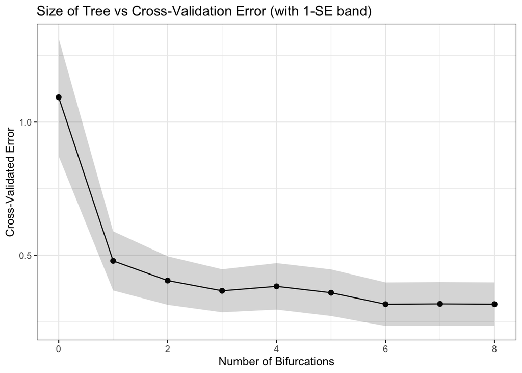

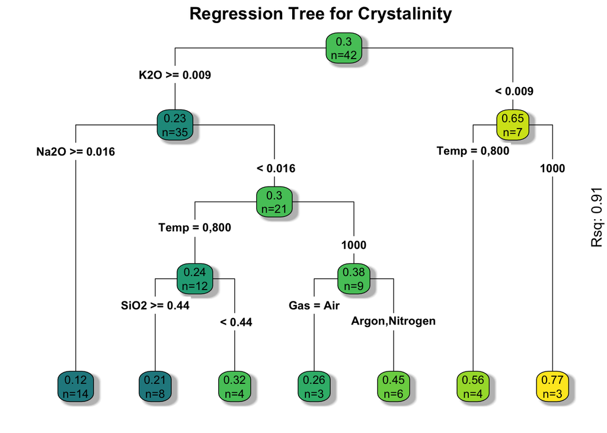

### 3.3 Specific Heat

Once again we analyze what characteristics and conditions contribute to a favorable high specific heat for the fly ash.

The variable that explains Specific Heat to the greatest degree is SO3 %, but just SO3 alone has terrible predictive power:

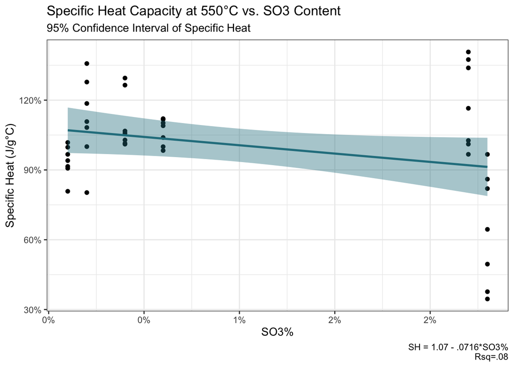

Specific Heat appears to a function of more of the components of a fly ash. We can expand this model using forward selection. The model that maximizes Adjusted Rsq is as follows:

```
##
## Call:
## lm(formula = SH ~ Gas + Fe2O3 + MgO + SO3, data = df)
##
## Residuals:
##      Min       1Q   Median       3Q      Max
## -0.24222 -0.06746  0.02692  0.06903  0.31485
##
## Coefficients:
##              Estimate Std. Error t value Pr(>|t|)
## (Intercept)   0.93247    0.06546  14.244 3.93e-16 ***
## GasArgon     -0.20108    0.05045  -3.986 0.000326 ***
## GasNitrogen  -0.23319    0.05045  -4.622 5.00e-05 ***
## GasNo Cycle  -0.13654    0.06179  -2.210 0.033759 *
## Fe2O3         2.11842    0.42525   4.982 1.70e-05 ***
## MgO          19.67930    2.25237   8.737 2.56e-10 ***
## SO3         -48.52768    5.17445  -9.378 4.42e-11 ***
## ---
## Signif. codes:  0 '***' 0.001 '**' 0.01 '*' 0.05 '.' 0.1 ' ' 1
##
## Residual standard error: 0.1236 on 35 degrees of freedom
## Multiple R-squared:  0.7642, Adjusted R-squared:  0.7238
## F-statistic: 18.91 on 6 and 35 DF,  p-value: 1.139e-09
```

This model is comparable to the result of a Lasso Regression:

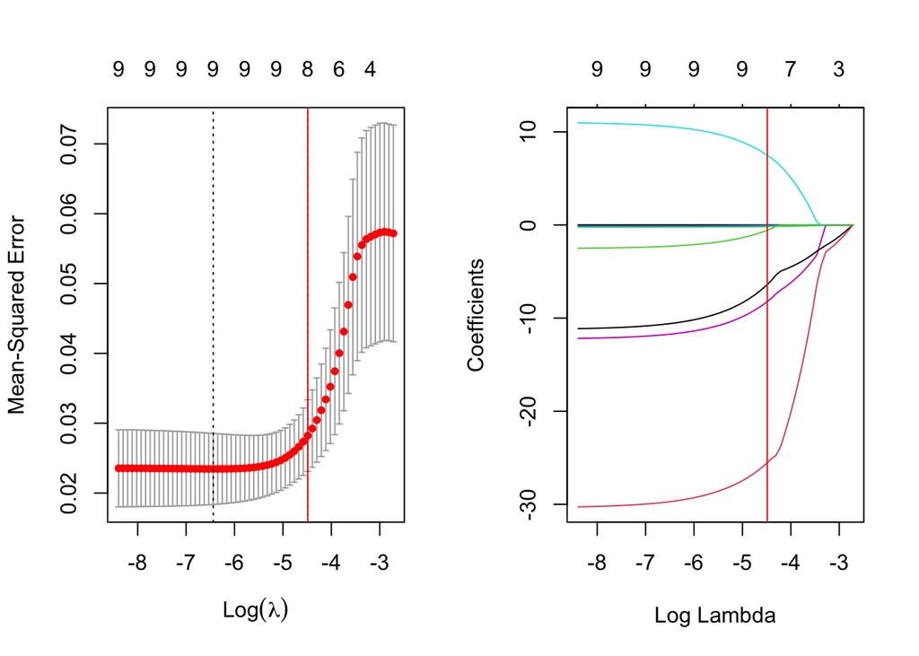

```
##  (Intercept)     GasArgon  GasNitrogen  GasNo Cycle          MgO          K2O
##   1.47030710  -0.13387895  -0.16598920  -0.05956341   7.48428275  -8.22467420
##         Na2O          SO3        Other
##  -6.39458942 -25.53242415  -0.56663472
```

```
## [1] "Rsqu: 0.76428324037922"
```

Notice the huge, and stable improvements from a simple linear regression

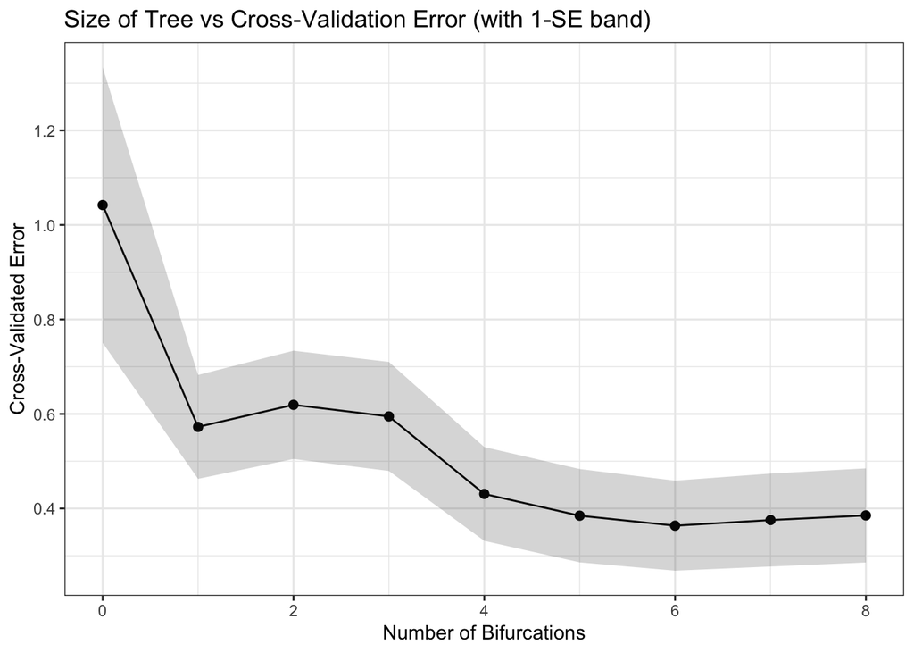

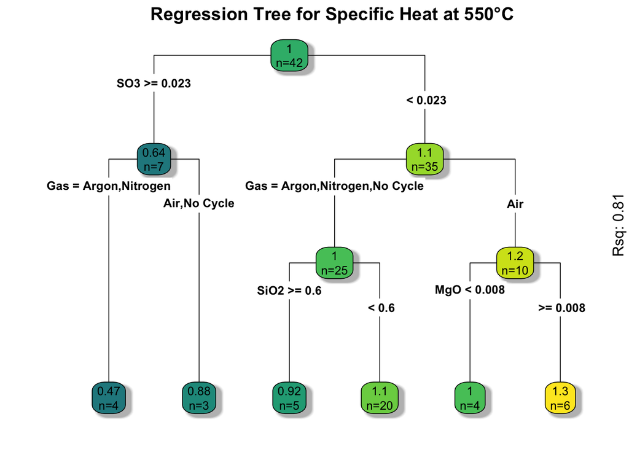

## 4 Conclusion

We can use this experiment and analysis to help update our understanding of how to use Fly ash as a Thermal Energy Storage (TES) substrate for Concentrated Solar Power (CSP) systems.

1. *High Solar Absorptance* can be attained by iron content greater then 8% and an inert gas environment.
2. *High Crystallinity Index %* can be attained by a very low K2O content (<.9%)
3. *High Specific Heat* can be attained by low SO3 content (< 2.3%), with additional benefits from an Air environment with high MgO content.

The analysis in this study was constrained by the low quantity of data. For further research on how to improve fly ash selection, a greater variety of fly ashes should be analyzed. Creating a larger dataset of fly ashes would allow us to determine what coal plants have produced the most useful fly ash. Due to the promising results, steps should be taken to build an experimental CSP generator that can be used to test fly ashes in real conditions.